# Wellons_HW3

Madelynn Wellons

9/7/21

Practice:

First I will copy the code Nico has in the practice section to make sure my packages are loaded, dataframes are imported, etc.

```r
library(tidyverse)
deck <- tibble(
  card = rep(
    c("ace",
      "deuce",
      "three",
      "four",
      "five",
      "six",
      "seven",
      "eight",
      "nine",
      "ten",
      "jack",
      "queen",
      "king"
    ),4),
  suit =
    rep(c(
      "diamonds",
      "hearts",
      "clubs",
      "spades"),
        each = 13),
  color = rep(c("red",
                "black"),
              each = 26)
)

glimpse(deck)
```

```
## Rows: 52
## Columns: 3
## $ card  <chr> "ace", "deuce", "three", "four", "five", "six", "seven", "eight"…
## $ suit  <chr> "diamonds", "diamonds", "diamonds", "diamonds", "diamonds", "dia…
## $ color <chr> "red", "red", "red", "red", "red", "red", "red", "red", "red", "…
```

```r
pr_black <- deck %>%
  filter(color == "black") %>%
  nrow()/nrow(deck)

pr_ace <- deck %>%
  filter(card == "ace") %>%
  nrow()/nrow(deck)

pr_black_and_ace <- deck %>%
  filter(card == "ace" & color == "black") %>%
  nrow()/nrow(deck)

pr_black + pr_ace - pr_black_and_ace
```

```
## [1] 0.5384615
```

Question 1:

For the first part when we are seeing the chances of getting a black card and a red card, we are looking for the probability that both of those are happening, so we would use the formula pr_black * pr_red. First we will create the value pr_red, then we will complete this multiplication. To think of this in another way, the chance of getting a black card first is .5, and then the chance of getting a red card after that (with replacement) is .5, so we would multiply those together to account for both of those probabilities (if order did not matter, then it would be .5 since we would be double counting red first then black, and black first then red).

```r
pr_red <- deck %>%
  filter(color == "red") %>%
  nrow()/nrow(deck)

pr_black * pr_red
```

```
## [1] 0.25
```

The probability of getting a black card and a red card with replacement in two draws is .25.

In order to answer the next question (probability of getting a king or an ace in a single draw), we will calculate the individual probabilities of either of these events happening and then add them together. We already have pr_ace, so we will create the value pr_king and then add those together.

```r
pr_king <- deck %>%
  filter(card == "king") %>%
  nrow()/nrow(deck)

pr_king + pr_ace
```

```
## [1] 0.1538462
```

The probability here is .1538462 (simplified as .15).

For the last question (the probability of getting 2 aces in 2 draws with replacement), we will multiple pr_ace by pr_ace.

```r
pr_ace * pr_ace
```

```
## [1] 0.00591716
```

The probability of this occuring is .00591716 (or .006).

Question 2:

In order to give my friend an example of 5 randomly sampled poker hands, I can use the sample_n function to give an example using the deck dataframe.

```r
sample_n(deck, 5)
```

```
## # A tibble: 5 × 3
##   card  suit   color
##   <chr> <chr>  <chr>
## 1 three clubs  black
## 2 king  clubs  black
## 3 deuce spades black
## 4 eight hearts red
## 5 king  spades black
```

In order to answer their next question about the total number of different hands you could draw in Poker, you would calculate the value of 52 choose 5- the formula being (n!/k!(n-k)!), but in R you can use the choose function to calculate it more easily.

```r
choose(52, 5)
```

```
## [1] 2598960
```

We can tell our friend that there are 2598960 different hands we can draw in poker.

Question 3:

In order to calculate the probability that each suit is represented in a hand, we would multiply the probability of choosing any suit to start with (which would just be 1- 52/52), then by the probability of selecting any of the 3 remaining suits, then the two remaining suits, then the last remaining suit, and then by 1 again to account for the final card because it does not matter which suit repeats itself (48/48)

```r
(52/52)*(39/51)*(26/50)*(13/49)*(48/48)
```

```
## [1] 0.1054982
```

The probability of this occurring is .1054982 (simplified to .11).

Question 4:

In order to answer their question about getting at least one Ace in a 5 card hand, we would add the probability of getting an Ace for each occurence without replacement.

```r
(4/52)+(4/51)+(4/50)+(4/49)+(4/48)
```

```
## [1] 0.4003204
```

The probability here is .4003204 (simplified to .4).

Question 5:

To calculate the number of combinations here, you would do 5+4+3+2+1=15, as there are 5 people that the first person could work with, 4 people that the second person could work with (because we are excluding the first person as they are already accounted for in the first calculation), 3 people the third person could work with, and so on.

Question 6:

In order to modify the code to account for order mattering, we would just need to adjust the filter to remove sets where it would pair the person with themselves- all other combinations, regardless of the order (therefore including both Alice_Bob and Bob_Alice as different values)

```r
df <- tibble(
  id   = 1:6,
  name = c('Alice', 'Bob', 'Charlie', 'Diane', 'Fred', 'Jenny')
)

df_pairs <- df %>%
  rename(id1 = id, name1 = name) %>%
  crossing(df %>%
             select(id2 = id, name2 = name)) |>
  filter(id1 != id2) |>
  unite(id, id1, id2) %>%
  unite(name, name1, name2)

df_pairs
```

```
## # A tibble: 30 × 2
##    id    name
##    <chr> <chr>
##  1 1_2   Alice_Bob
##  2 1_3   Alice_Charlie
##  3 1_4   Alice_Diane
##  4 1_5   Alice_Fred
##  5 1_6   Alice_Jenny
##  6 2_1   Bob_Alice
##  7 2_3   Bob_Charlie
##  8 2_4   Bob_Diane
##  9 2_5   Bob_Fred
## 10 2_6   Bob_Jenny
## # … with 20 more rows
```

An analytical version of this would be 6*5= 30, because we are taking the possibility of any of the 6 people being in the first position and then multiplying that by the possibility of any of the remaining 5 being in the second position.

Question 7:

First, we will make the dataframes for each die. Starting with the simplest (the fair die), we can just have this be a simple vector of 1, 2, 3, 4, 5, and 6. Next, for the loaded die that lands on 6 50% of the time, we can adjust the vector to account for the probabilities here- if we got rid of the 6 value, there would be 5 other options (each equally likely to be chosen), so if we want the 6 to account for the other half of the potential dice rolls then there would be another 5 values of 6 in the vector (1, 2, 3, 4, 5, 6, 6, 6, 6, 6). Finally, for the loaded die with 5 and 6 each having a 1/3 probability, since there are 4 other values that should be accounting for the remaining 1/3 of options, we can add another 4 values of 5 and 4 values of 6 for this last vector (1, 2, 3, 4, 5, 5, 5, 5, 6, 6, 6, 6).

```r
fair_die <- c(1, 2, 3, 4, 5, 6)
loaded_die6 <- c(1, 2, 3, 4, 5, 6, 6, 6, 6, 6)
loaded_die_56 <- c(1, 2, 3, 4, 5, 5, 5, 5, 6, 6, 6, 6)
```

Next, we can draw these 3 samples using the sample command (and simultaneously saving them as another vector so that we can plot them and get the sum values we need in the last step).

```r
set.seed(33)
fair_die_sample <- sample(fair_die, 1000, replace = TRUE)
loaded_die6_sample <- sample(loaded_die6, 1000, replace = TRUE)
loaded_die56_sample <- sample(loaded_die_56, 1000, replace = TRUE)
```

First before plotting, we will need to save these sample vectors as dataframes. We can do that using the as.data.frame function:

```r
df_fair_die_sample <- as.data.frame(fair_die_sample)
df_loaded_die6_sample <- as.data.frame(loaded_die6_sample)
df_loaded_die56_sample <- as.data.frame(loaded_die56_sample)
```

Since we only have the one variable (dice values) we can build histograms. First, we will plot the fair_die_sample histogram and also calculate the average using the mean function (using the vector for the mean function to make the coding easier).

```r
mean(fair_die_sample)
```

```
## [1] 3.47
```

The mean of the fair die sample is 3.47.

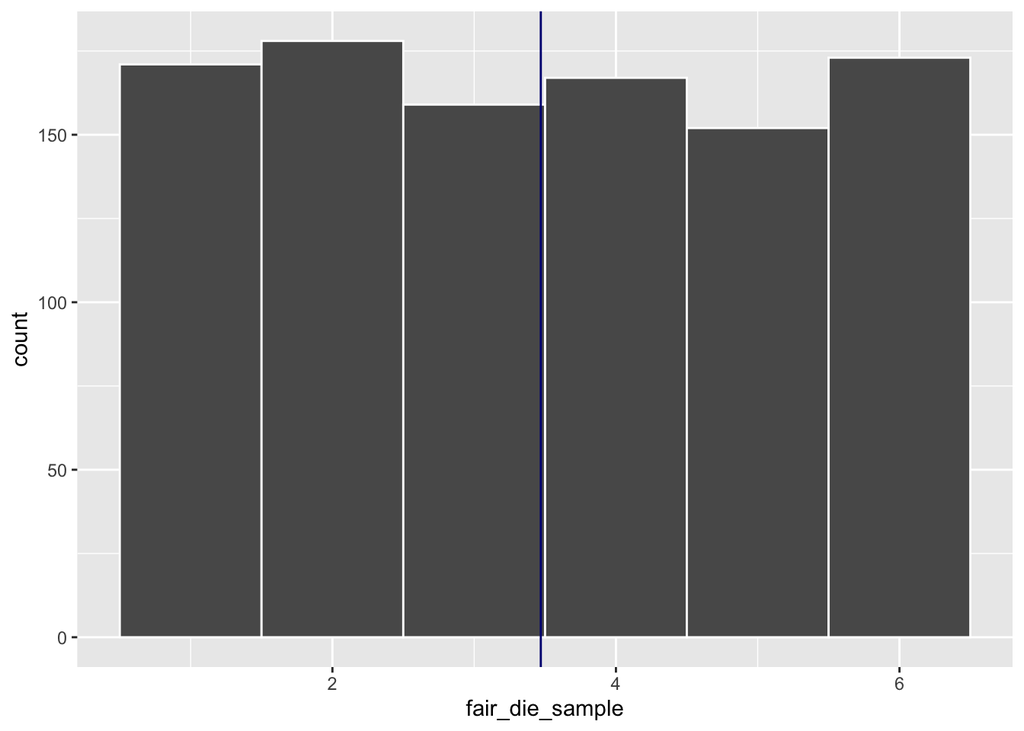

```r
ggplot(df_fair_die_sample, aes(x = fair_die_sample)) +
  geom_histogram(binwidth = 1, color = "white") +
  geom_vline(xintercept = 3.47, color = "navy blue")
```

Now, we will do the same thing for the second die’s sample (loaded die 6).

```r
mean(loaded_die6_sample)
```

```
## [1] 4.531
```

The mean here is 4.531.

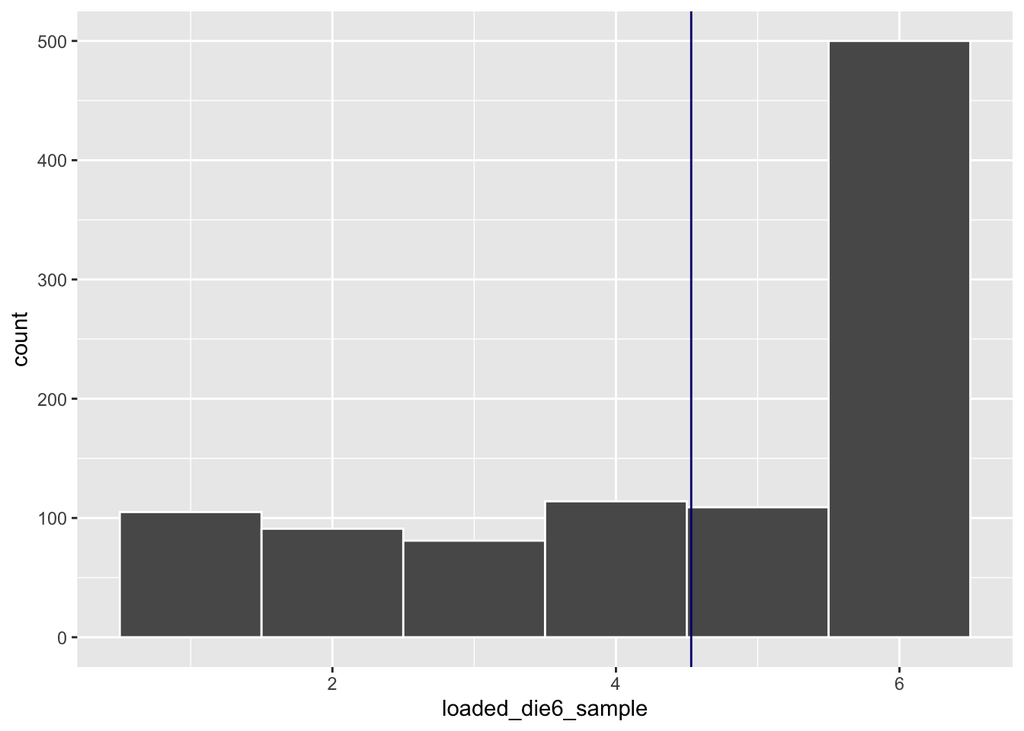

```r
ggplot(df_loaded_die6_sample, aes(x = loaded_die6_sample)) +
  geom_histogram(binwidth = 1, color = "white") +
  geom_vline(xintercept = 4.531, color = "navy blue")
```

Now finally, we will do the same for the last die (loaded die 56).

```r
mean(loaded_die56_sample)
```

```
## [1] 4.547
```

The mean here is 4.547.

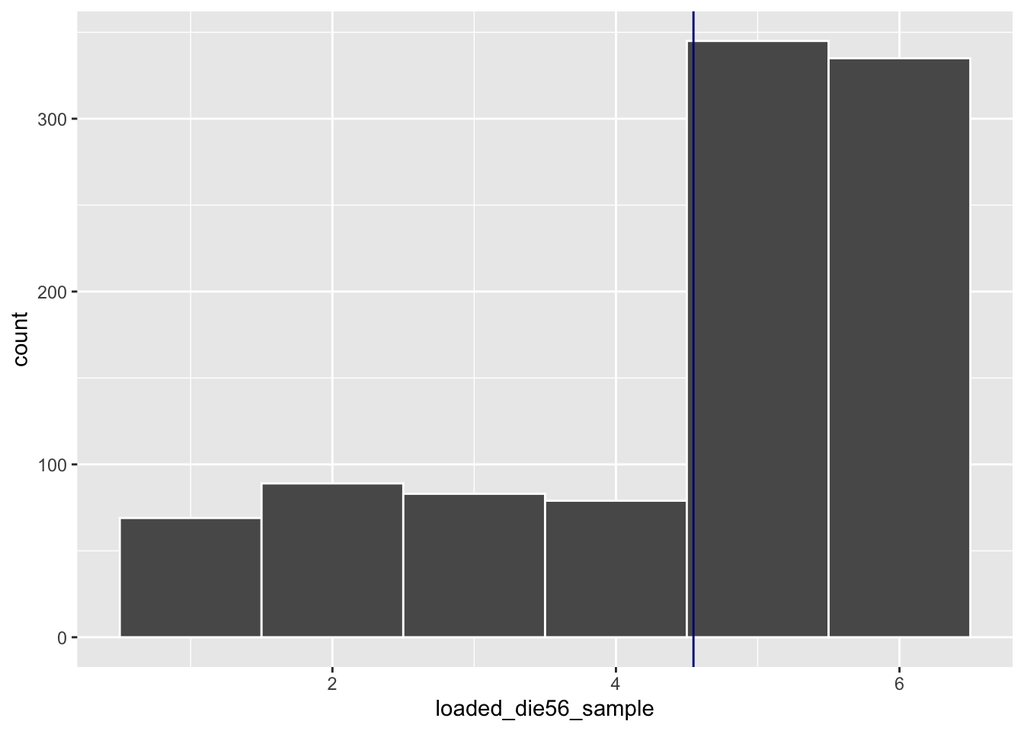

```r
ggplot(df_loaded_die56_sample, aes(x = loaded_die56_sample)) +
  geom_histogram(binwidth = 1, color = "white") +
  geom_vline(xintercept = 4.547, color = "navy blue")
```